# Aula 3 Regressão

19/08/2021

Para os exercícios a seguir: (1) efetue a regressão linear; (2) utilize a função summary e encontre os coeficientes de regressão e o valor de R2; (3) plote o gráfico de dispersão e a reta de regressão; (4) plote o histograma dos resíduos; (5) plote o gráfico dos resíduos em função do preditor; (6) plote o gráfico dos resíduos normalizados em função do preditor; (7) utilize a função *lmIC* para determinar a banda de confiança e a banda de predição, e para fazer inferência sobre um valor qualquer escohido; e (9) comente os resultados de cada item.

As bases de dados utilizadas nos exercícios estão disponíveis em [RDatasets](https://vincentarelbundock.github.io/Rdatasets/datasets.html).

### Exercício 1

Baixe a base de dados *CASchools*, leia o dicionário de dados, escolha duas variáveis e efetue os comandos de 1 a 9.

Vamos ver a relação entre as variáveis computer e teachers, ambas representando, respectivamente, o número de computadores e o número de professores.

```r
df = read.csv('CASchools.csv')

# (1) efetue a regressão linear;
formula = computer ~ teachers
x = df$teachers
y = df$computer
modelo = lm(formula, data = df)

# (2) utilize a função summary e encontre os coeficientes de regressão e o valor de R2;
summary(modelo)
```

```
##
## Call:
## lm(formula = formula, data = df)
##
## Residuals:
##      Min       1Q   Median       3Q      Max
## -1070.17   -39.67   -11.26    24.57   664.87
##
## Coefficients:
##             Estimate Std. Error t value Pr(>|t|)
## (Intercept) 19.27312    9.12386   2.112   0.0352 *
## teachers     2.20126    0.04005  54.956   <2e-16 ***
## ---
## Signif. codes:  0 '***' 0.001 '**' 0.01 '*' 0.05 '.' 0.1 ' ' 1
##
## Residual standard error: 154.1 on 418 degrees of freedom
## Multiple R-squared:  0.8784, Adjusted R-squared:  0.8781
## F-statistic:  3020 on 1 and 418 DF,  p-value: < 2.2e-16
```

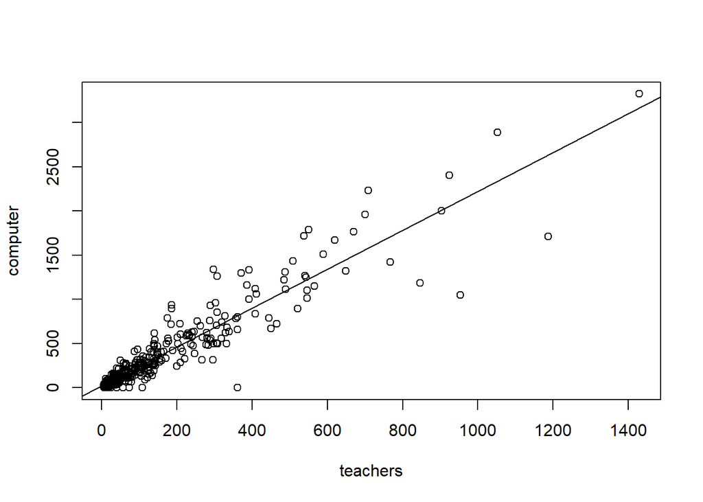

```r
# (3) plote o gráfico de dispersão e a reta de regressão;
plot(formula, data = df)
abline(modelo)
```

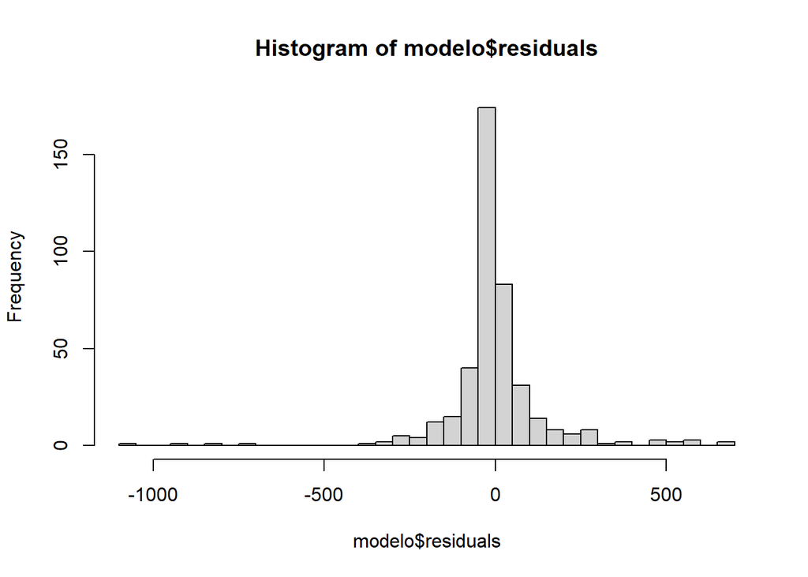

```r
# (4) plote o histograma dos resíduos;
hist(modelo$residuals, breaks=30)
```

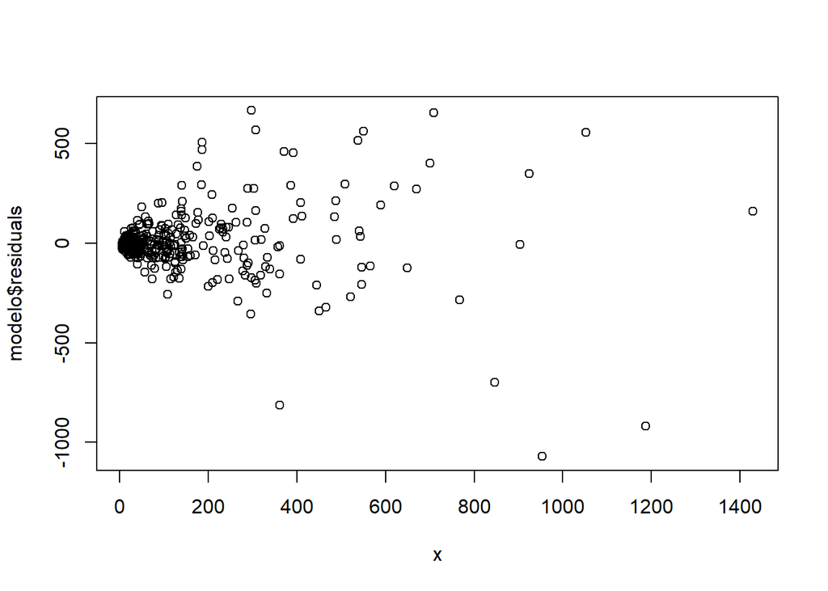

```r
# (5) plote o gráfico dos resíduos em função do preditor;
plot(x, modelo$residuals)
```

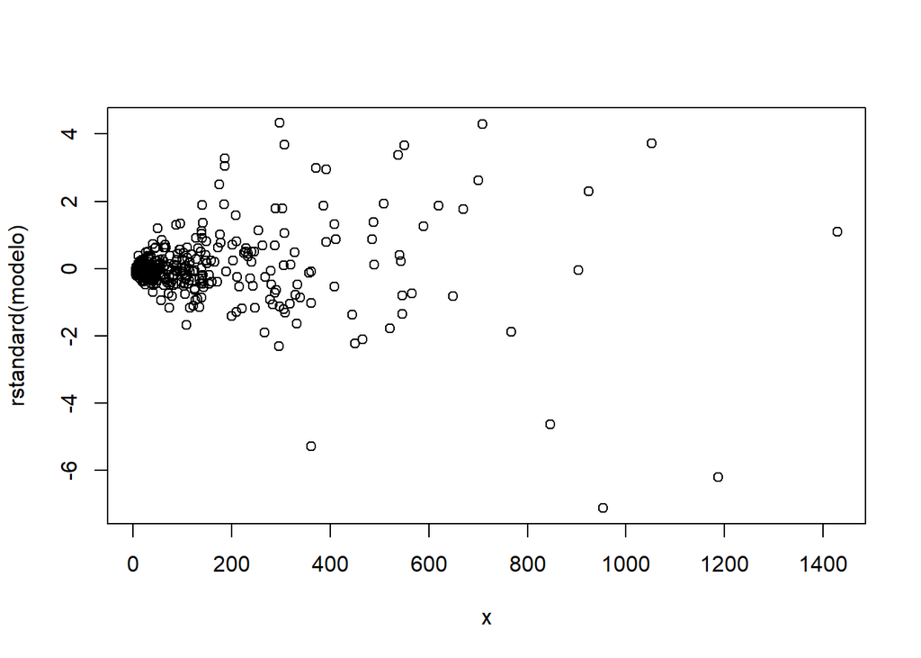

```r
# (6) plote o gráfico dos resíduos normalizados em função do preditor;
plot(x, rstandard(modelo))
```

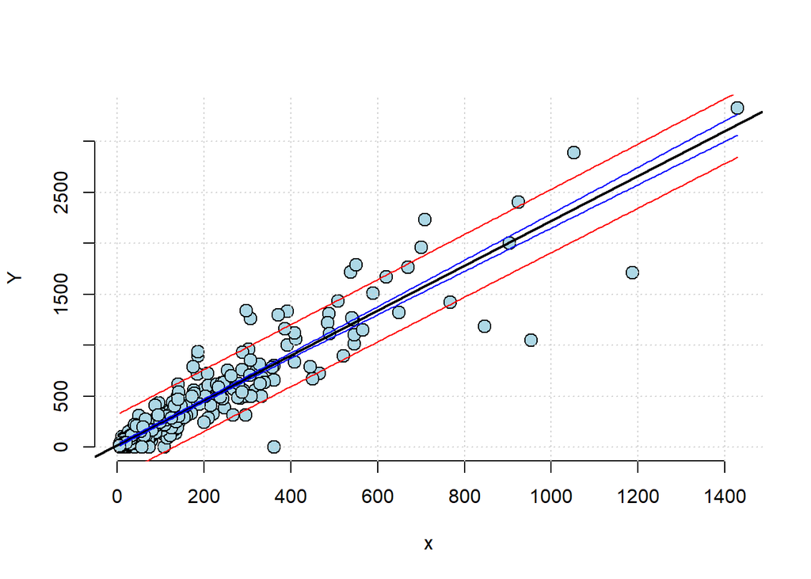

```r
# (7) utilize a função *lmIC* para determinar a banda de confiança e a banda de predição,
lmIC(x, y)
```

```r
# (8) e para fazer inferência sobre um valor qualquer escolhido;
dfpred = data.frame(teachers=400)
predict(modelo, dfpred, interval='confidence')
```

```
##        fit      lwr      upr
## 1 899.7751 873.8249 925.7254
```

```r
predict(modelo, dfpred, interval='prediction')
```

```
##        fit      lwr      upr
## 1 899.7751 595.8163 1203.734
```

```r
# (9) comente os resultados de cada item.
```

O que é possível perceber é que a quantidade de professores de uma escola é (obviamente) um bom preditor para a quantidades de computadores que a escola tem. Apesar de simples e de ter um bom R2 (quase 90%), o gráfico de resíduos não é normal, indicando que há também outras variáveis que poderiam (e deveriam) ser usadas na definição do modelo.

### Exercício 2

Baixe a base de dados *CPS 1985*, leia o dicionário de dados, escolha duas variáveis e efetue os comandos de 1 a 9.

Vamos ver a relação entre as variáveis education e wage, ambas representando, respectivamente, a quantidade de anos de escolaridade da pessoa e sua renda em dólares por hora.

```r
df = read.csv('CPS1985.csv')

# (1) efetue a regressão linear;
formula = wage ~ education
x = df$education
y = df$wage
modelo = lm(formula, data = df)

# (2) utilize a função summary e encontre os coeficientes de regressão e o valor de R2;
summary(modelo)
```

```
##
## Call:
## lm(formula = formula, data = df)
##
## Residuals:
##    Min     1Q Median     3Q    Max
## -7.911 -3.260 -0.760  2.240 34.740
##
## Coefficients:
##             Estimate Std. Error t value Pr(>|t|)
## (Intercept) -0.74598    1.04545  -0.714    0.476
## education    0.75046    0.07873   9.532   <2e-16 ***
## ---
## Signif. codes:  0 '***' 0.001 '**' 0.01 '*' 0.05 '.' 0.1 ' ' 1
##
## Residual standard error: 4.754 on 532 degrees of freedom
## Multiple R-squared:  0.1459, Adjusted R-squared:  0.1443
## F-statistic: 90.85 on 1 and 532 DF,  p-value: < 2.2e-16
```

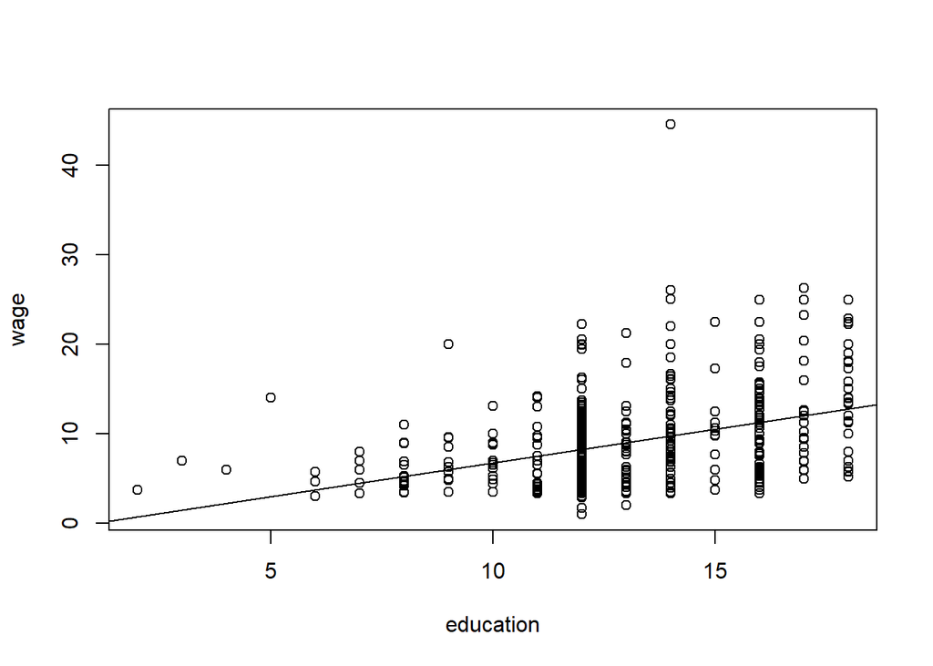

```r
# (3) plote o gráfico de dispersão e a reta de regressão;
plot(formula, data = df)
abline(modelo)
```

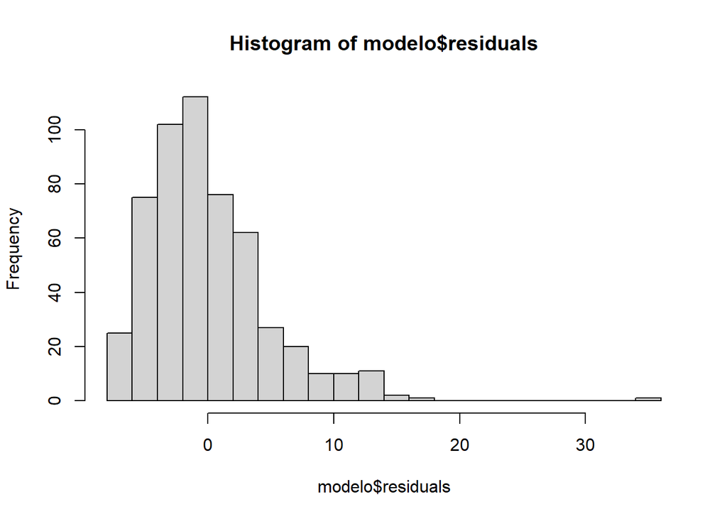

```r
# (4) plote o histograma dos resíduos;
hist(modelo$residuals, breaks=30)
```

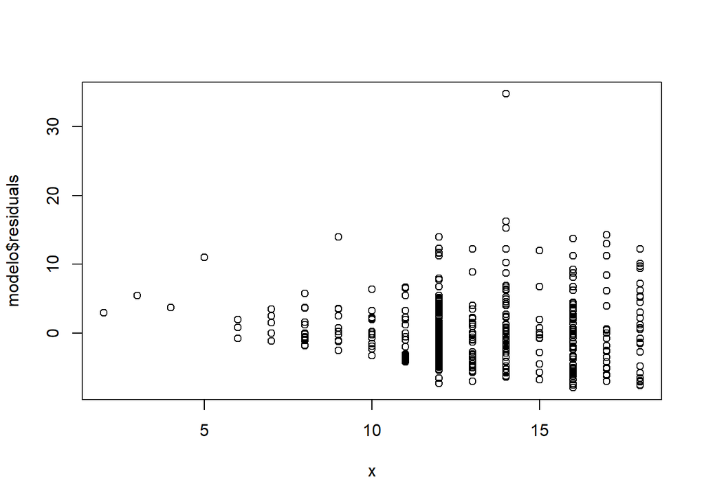

```r
# (5) plote o gráfico dos resíduos em função do preditor;
plot(x, modelo$residuals)
```

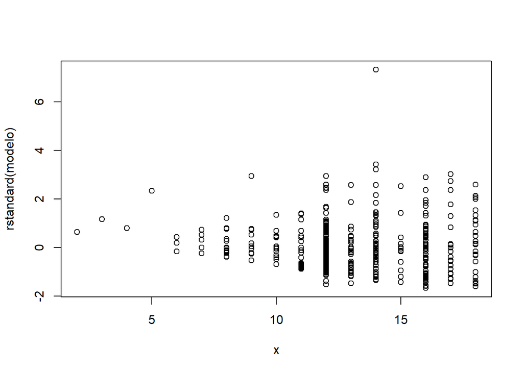

```r
# (6) plote o gráfico dos resíduos normalizados em função do preditor;
plot(x, rstandard(modelo))
```

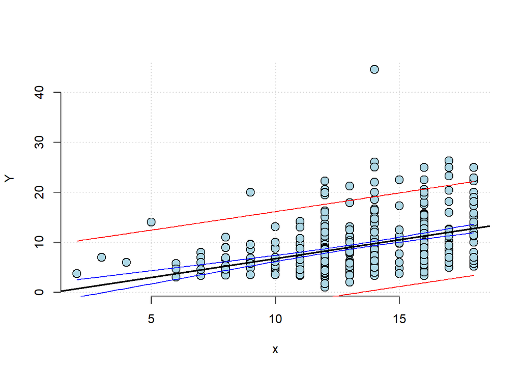

```r
# (7) utilize a função *lmIC* para determinar a banda de confiança e a banda de predição,
lmIC(x, y)
```

```r
# (8) e para fazer inferência sobre um valor qualquer escolhido;
dfpred = data.frame(education=10)
predict(modelo, dfpred, interval='confidence')
```

```
##        fit      lwr      upr
## 1 6.758628 6.141119 7.376137
```

```r
predict(modelo, dfpred, interval='prediction')
```

```
##        fit       lwr      upr
## 1 6.758628 -2.600655 16.11791
```

```r
# (9) comente os resultados de cada item.
```

Podemos notar que há alguma relação entre education e wage. Entretanto, é uma relação relativamente fraca e a variação dos resíduos aumenta consideravelmente com o aumento de education. Definitivamente não é o melhor preditor dessa base.

### Exercício 3

Baixe a base de dados *Fertility*, leia o dicionário de dados, escolha duas variáveis e efetue os comandos de 1 a 9.

Essa base de dados possui praticamente apenas variáveis categórias. As únicas numéricas são age (idade da mãe no censo) e work (número de semanas que a mãe trabalhou em 1979). Por isso, mesmo que não tenha muito cabimento, para efeitos do exercício, vamos tentar relacionar as duas.

```r
df = read.csv('Fertility.csv')

# (1) efetue a regressão linear;
formula = age ~ work
x = df$work
y = df$age
modelo = lm(formula, data = df)

# (2) utilize a função summary e encontre os coeficientes de regressão e o valor de R2;
summary(modelo)
```

```
##
## Call:
## lm(formula = formula, data = df)
##
## Residuals:
##     Min      1Q  Median      3Q     Max
## -9.9609 -2.0659  0.7275  2.9341  4.9341
##
## Coefficients:
##              Estimate Std. Error t value Pr(>|t|)
## (Intercept) 30.065932   0.008839 3401.66   <2e-16 ***
## work         0.017212   0.000305   56.43   <2e-16 ***
## ---
## Signif. codes:  0 '***' 0.001 '**' 0.01 '*' 0.05 '.' 0.1 ' ' 1
##
## Residual standard error: 3.365 on 254652 degrees of freedom
## Multiple R-squared:  0.01235,    Adjusted R-squared:  0.01235
## F-statistic:  3185 on 1 and 254652 DF,  p-value: < 2.2e-16
```

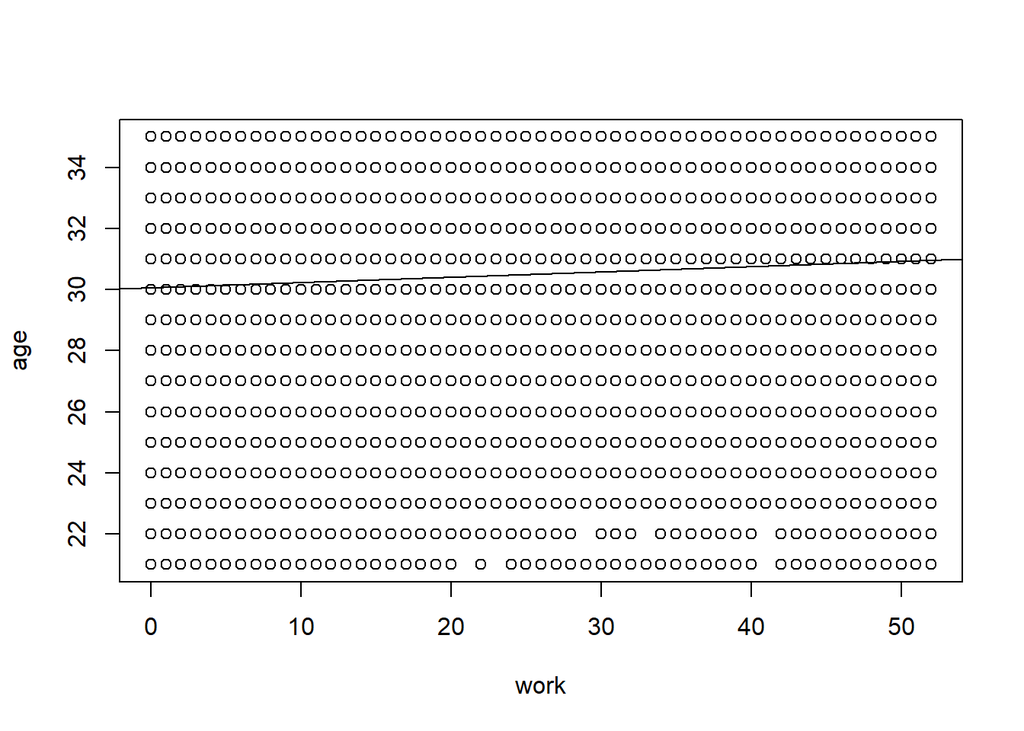

```r
# (3) plote o gráfico de dispersão e a reta de regressão;
plot(formula, data = df)
abline(modelo)
```

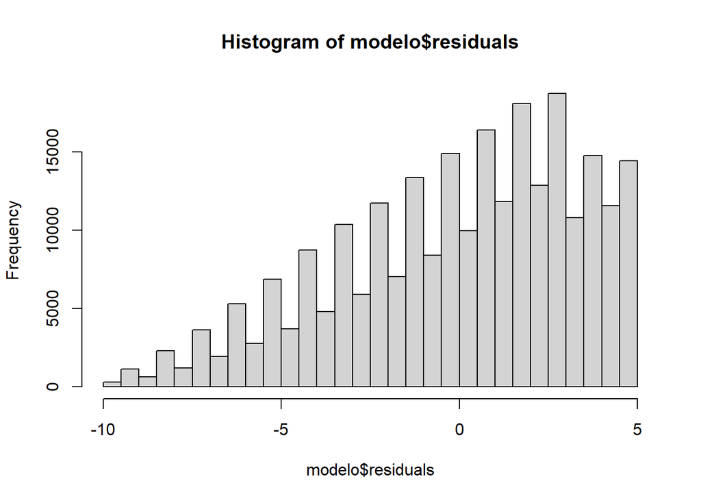

```r
# (4) plote o histograma dos resíduos;
hist(modelo$residuals, breaks=30)
```

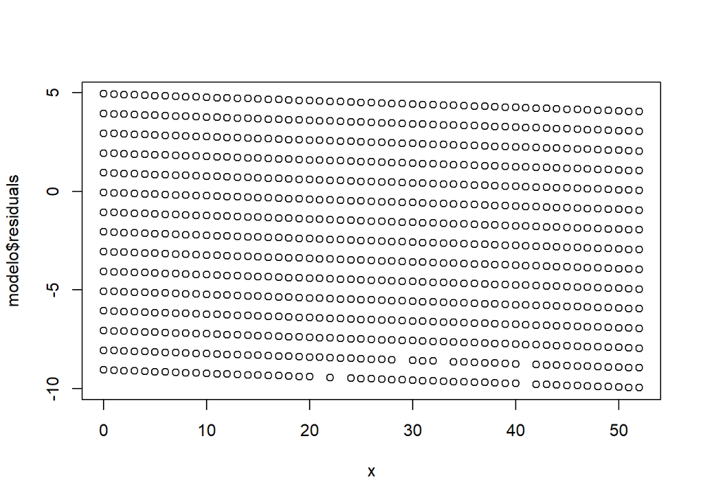

```r
# (5) plote o gráfico dos resíduos em função do preditor;
plot(x, modelo$residuals)
```

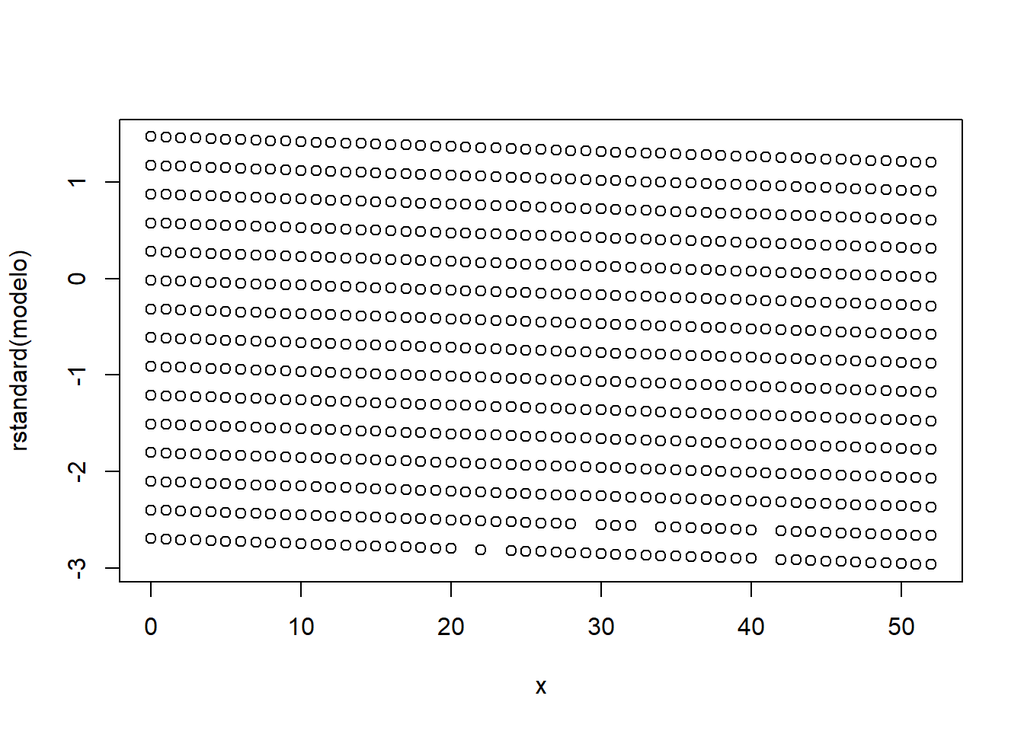

```r
# (6) plote o gráfico dos resíduos normalizados em função do preditor;
plot(x, rstandard(modelo))
```

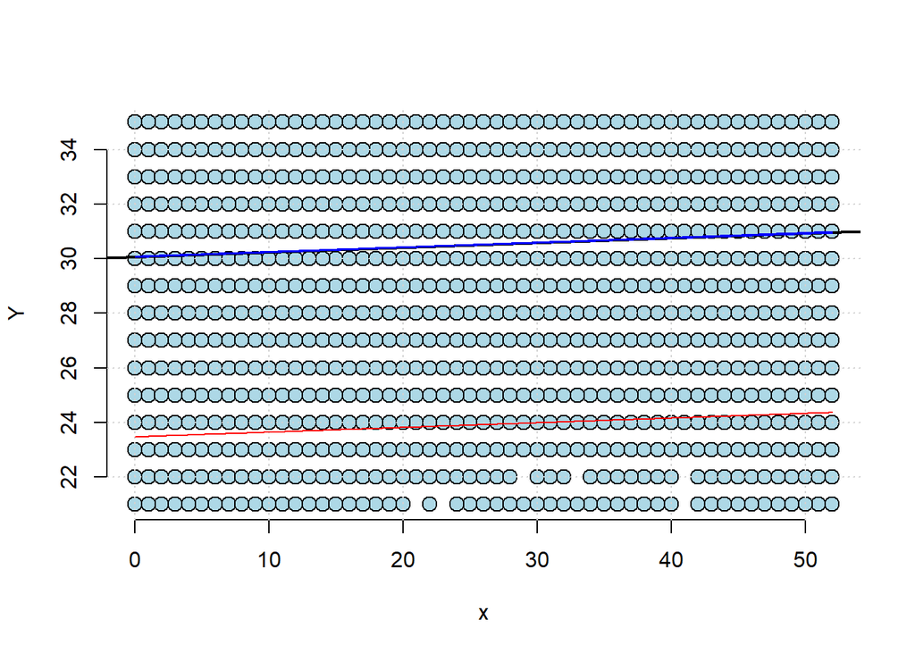

```r
# (7) utilize a função *lmIC* para determinar a banda de confiança e a banda de predição,
lmIC(x, y)
```

```r
# (8) e para fazer inferência sobre um valor qualquer escolhido;
dfpred = data.frame(work=25)
predict(modelo, dfpred, interval='confidence')
```

```
##        fit      lwr      upr
## 1 30.49622 30.48267 30.50977
```

```r
predict(modelo, dfpred, interval='prediction')
```

```
##        fit      lwr      upr
## 1 30.49622 23.89997 37.09247
```

```r
# (9) comente os resultados de cada item.
```

Conforme esperado, vemos que não há relação alguma entre essas variáveis. Assim, considerando o ditado “garbage in, garbage out”, criamos um modelo cuja ideia já não fazia sentido e o resultado, claro, foi todo lixo.

### Exercício 4

Baixe a base de dados *EquationCitations*, leia o dicionário de dados, escolha duas variáveis e efetue os comandos de 1 a 9.

Essa base representa a análise de citações de artigos sobre biologia evolucionária publicados em 1998 em 3 revistas. Vamos usar duas variáveis. A primeira, equations, indica a quantidade de equações no artigo. A segunda, cites, a variável dependente, indica a quantidade de citações que o artigo recebeu. Essa é uma questão interessante pois indicará, no final, se existe alguma relação entre a quantidade de citações que um artigo recebe e a quantidade de equações usadas no texto.

```r
df = read.csv('EquationCitations.csv')

# (1) efetue a regressão linear;
formula = cites ~ equations
x = df$equations
y = df$cites
modelo = lm(formula, data = df)

# (2) utilize a função summary e encontre os coeficientes de regressão e o valor de R2;
summary(modelo)
```

```
##
## Call:
## lm(formula = formula, data = df)
##
## Residuals:
##    Min     1Q Median     3Q    Max
## -52.95 -32.95 -15.01  11.15 350.05
##
## Coefficients:
##             Estimate Std. Error t value Pr(>|t|)
## (Intercept) 53.94781    2.29634  23.493   <2e-16 ***
## equations   -0.09363    0.23309  -0.402    0.688
## ---
## Signif. codes:  0 '***' 0.001 '**' 0.01 '*' 0.05 '.' 0.1 ' ' 1
##
## Residual standard error: 53.63 on 647 degrees of freedom
## Multiple R-squared:  0.0002493,  Adjusted R-squared:  -0.001296
## F-statistic: 0.1614 on 1 and 647 DF,  p-value: 0.688
```

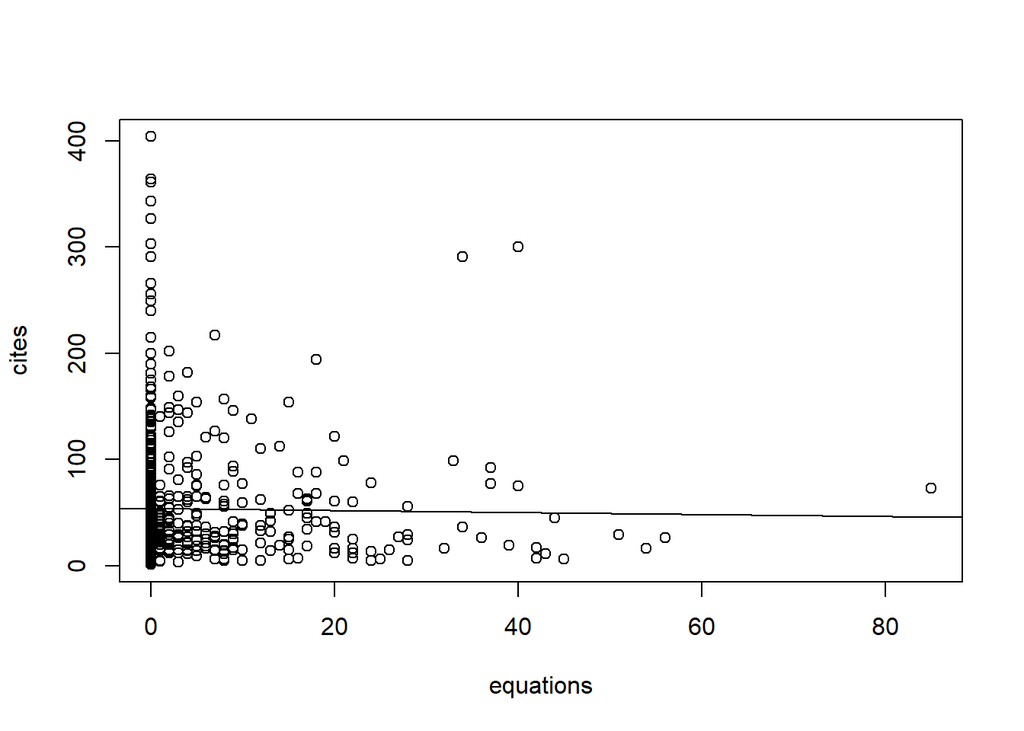

```r
# (3) plote o gráfico de dispersão e a reta de regressão;
plot(formula, data = df)
abline(modelo)
```

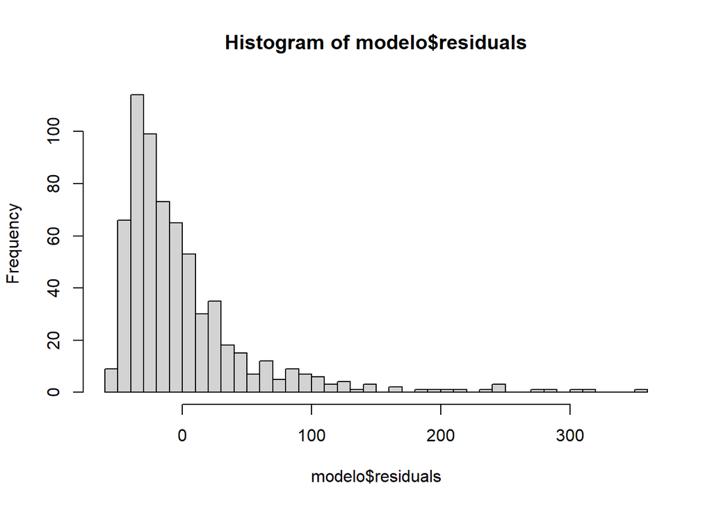

```r
# (4) plote o histograma dos resíduos;
hist(modelo$residuals, breaks=30)
```

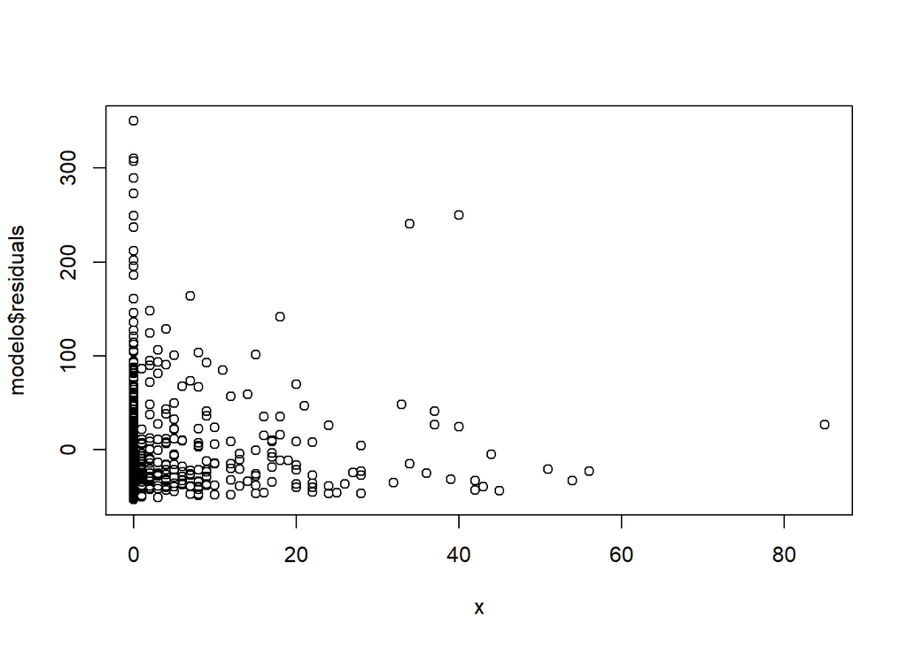

```r
# (5) plote o gráfico dos resíduos em função do preditor;
plot(x, modelo$residuals)
```

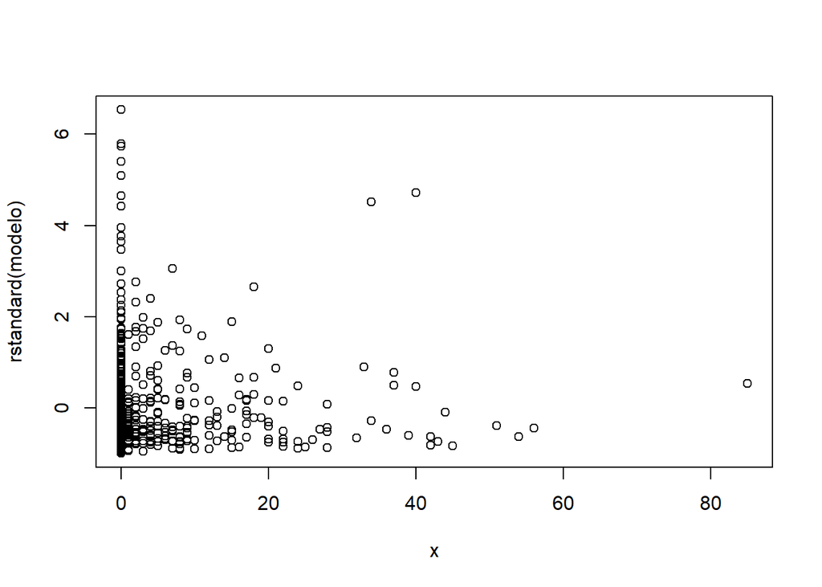

```r
# (6) plote o gráfico dos resíduos normalizados em função do preditor;
plot(x, rstandard(modelo))
```

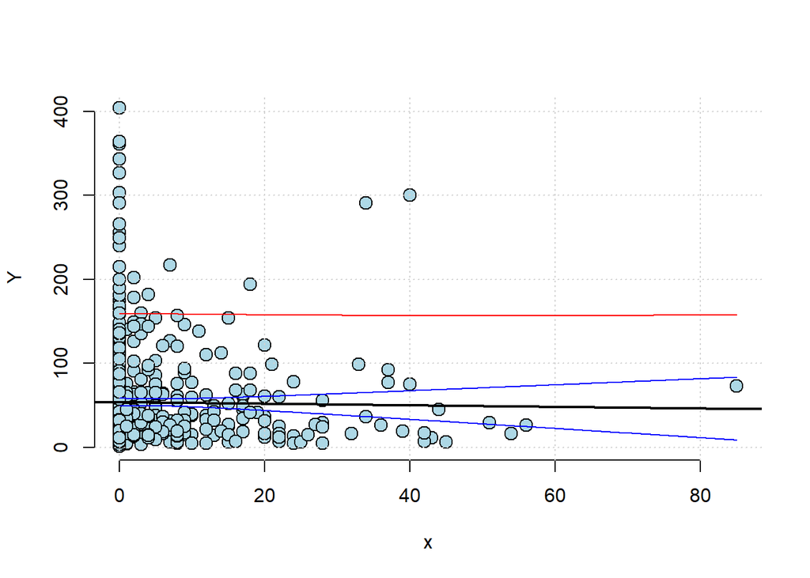

```r
# (7) utilize a função *lmIC* para determinar a banda de confiança e a banda de predição,
lmIC(x, y)
```

```r
# (8) e para fazer inferência sobre um valor qualquer escolhido;
dfpred = data.frame(equations=5)
predict(modelo, dfpred, interval='confidence')
```

```
##        fit      lwr     upr
## 1 53.47966 49.31723 57.6421
```

```r
predict(modelo, dfpred, interval='prediction')
```

```
##        fit       lwr      upr
## 1 53.47966 -51.91333 158.8727
```

```r
# (9) comente os resultados de cada item.
```

A conclusão aqui é que o número de equações não é foi um bom preditor para a quantidade de citações que um artigo publicado em 1998 da área de biologia evolucionária recebeu.

### Exercício 5

Baixe a base de dados *OECDGas*, leia o dicionário de dados, escolha duas variáveis e efetue os comandos de 1 a 9.

```r
df = read.csv('OECDGas.csv')

# (1) efetue a regressão linear;
formula = gas ~ year
x = df$year
y = df$gas
modelo = lm(formula, data = df)

# (2) utilize a função summary e encontre os coeficientes de regressão e o valor de R2;
summary(modelo)
```

```
##
## Call:
## lm(formula = formula, data = df)
##
## Residuals:
##     Min      1Q  Median      3Q     Max
## -0.7199 -0.3481 -0.1594  0.2299  1.7869
##
## Coefficients:
##              Estimate Std. Error t value Pr(>|t|)
## (Intercept) 52.569831  10.360215   5.074 6.42e-07 ***
## year        -0.024517   0.005262  -4.660 4.56e-06 ***
## ---
## Signif. codes:  0 '***' 0.001 '**' 0.01 '*' 0.05 '.' 0.1 ' ' 1
##
## Residual standard error: 0.533 on 340 degrees of freedom
## Multiple R-squared:  0.06002,    Adjusted R-squared:  0.05726
## F-statistic: 21.71 on 1 and 340 DF,  p-value: 4.556e-06
```

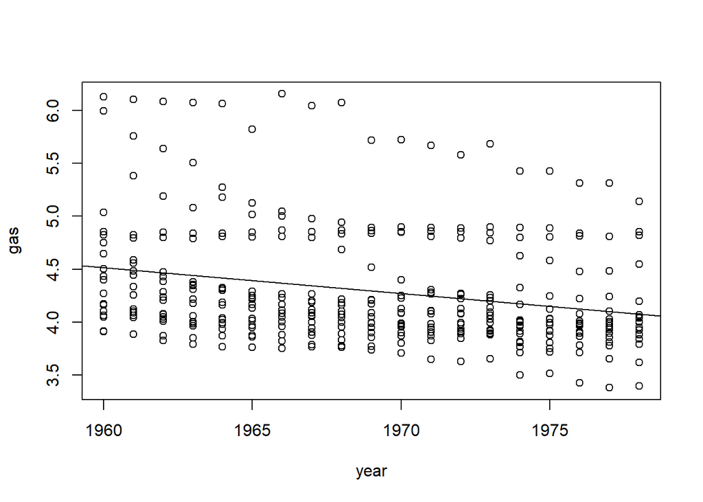

```r
# (3) plote o gráfico de dispersão e a reta de regressão;
plot(formula, data = df)
abline(modelo)
```

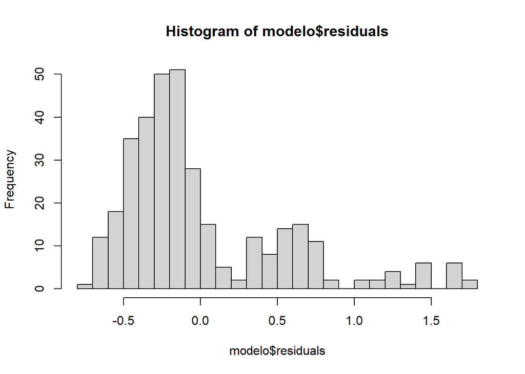

```r
# (4) plote o histograma dos resíduos;
hist(modelo$residuals, breaks=30)
```

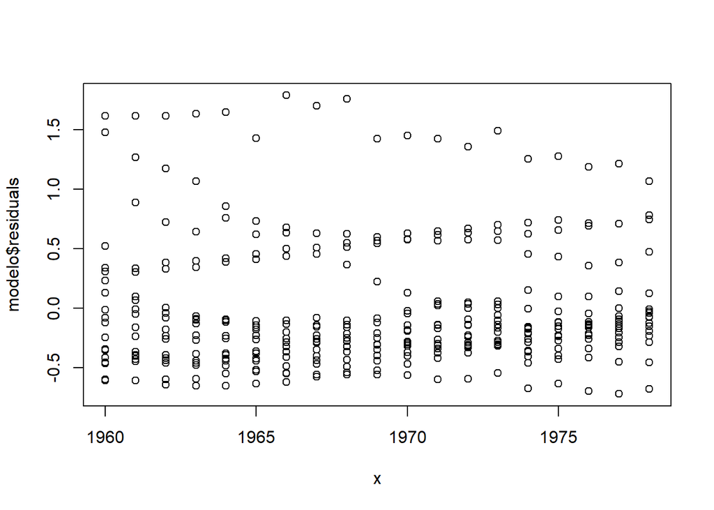

```r
# (5) plote o gráfico dos resíduos em função do preditor;
plot(x, modelo$residuals)
```

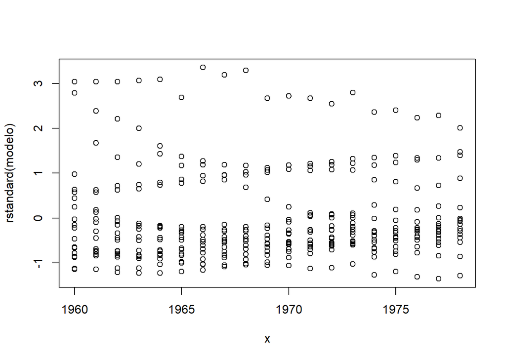

```r
# (6) plote o gráfico dos resíduos normalizados em função do preditor;
plot(x, rstandard(modelo))
```

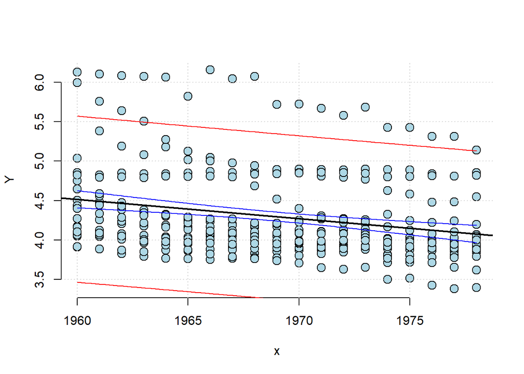

```r
# (7) utilize a função *lmIC* para determinar a banda de confiança e a banda de predição,
lmIC(x, y)
```

```r
# (8) e para fazer inferência sobre um valor qualquer escolhido;
dfpred = data.frame(year=1970)
predict(modelo, dfpred, interval='confidence')
```

```
##        fit      lwr      upr
## 1 4.271725 4.214102 4.329349
```

```r
predict(modelo, dfpred, interval='prediction')
```

```
##        fit      lwr      upr
## 1 4.271725 3.221828 5.321623
```

```r
# (9) comente os resultados de cada item.
```

Há uma tendência de diminuição na gasolina por carro com o passar dos anos (o coeficiente é negativo, estatisticamente diferente de 0 com nível de significância de 95%). Nota-se, porém, que o R2 é bem baixo, indicando que o ano, sozinho, explica pouca variação. De certa forma isso é esperado, pois cada país deve ter um comportamento diferente e, nesse exercício, combinamos todos eles na mesma base em vez de separar apenas um país.

O gráfico dos resíduos também não mostra normalidade, e a suspeita aqui é, de novo, o fato de termos considerado todos os países simultaneamente. Poderíamos fazer o exercício novamente considerando também a variável categória country como entrada. Mas isso é tema para outra aula.

### Exercício 6

Baixe a base de dados *SwissLabor*, leia o dicionário de dados, escolha duas variáveis e efetue os comandos de 1 a 9.

Trata-se de base sobre saúde na Suíça em 1981. Há 3 variáveis interessantes, education, youngkids e oldkids que representam a quantidade de anos de ensino formal, o total de filhos abaixo de 7 anos de idade e acima de 7 anos de idade. A partir dessas duas últimas podemos criar uma variável kids com a soma delas e usar essa variável como variável dependente de education para verificar se education pode ser uma preditora de kids.

```r
df = read.csv('SwissLabor.csv')

# (1) efetue a regressão linear;
df$kids = df$youngkids + df$oldkids
formula = kids ~ education
x = df$education
y = df$kids
modelo = lm(formula, data = df)

# (2) utilize a função summary e encontre os coeficientes de regressão e o valor de R2;
summary(modelo)
```

```
##
## Call:
## lm(formula = formula, data = df)
##
## Residuals:
##     Min      1Q  Median      3Q     Max
## -1.3611 -1.2789 -0.2789  0.7074  4.7142
##
## Coefficients:
##             Estimate Std. Error t value Pr(>|t|)
## (Intercept) 1.230957   0.121658  10.118   <2e-16 ***
## education   0.006851   0.012427   0.551    0.582
## ---
## Signif. codes:  0 '***' 0.001 '**' 0.01 '*' 0.05 '.' 0.1 ' ' 1
##
## Residual standard error: 1.114 on 870 degrees of freedom
## Multiple R-squared:  0.0003492,  Adjusted R-squared:  -0.0007998
## F-statistic: 0.3039 on 1 and 870 DF,  p-value: 0.5816
```

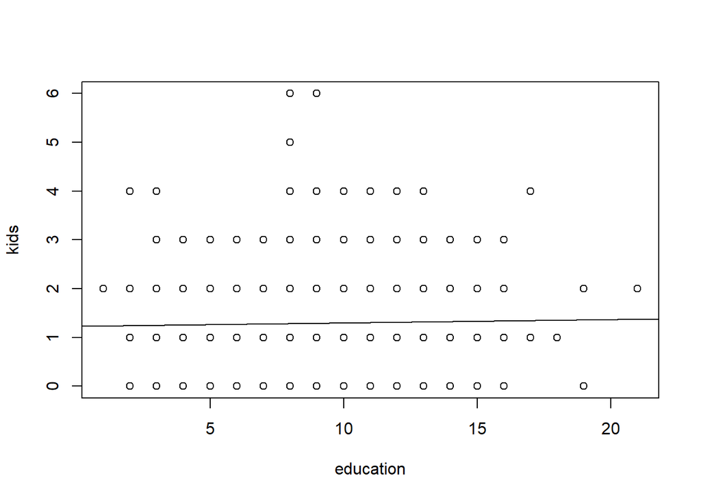

```r
# (3) plote o gráfico de dispersão e a reta de regressão;
plot(formula, data = df)
abline(modelo)
```

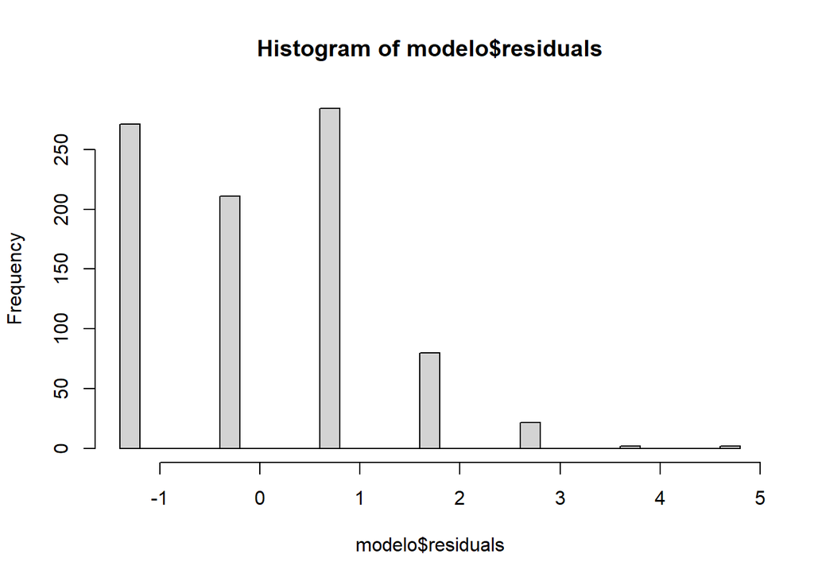

```r
# (4) plote o histograma dos resíduos;
hist(modelo$residuals, breaks=30)
```

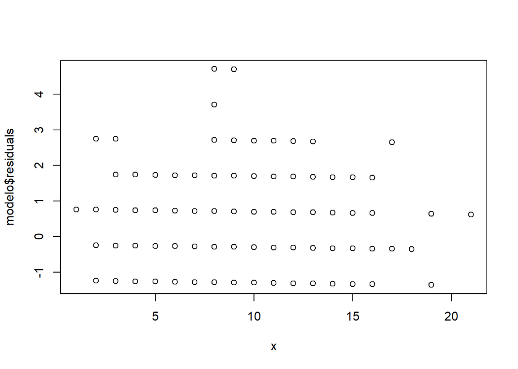

```r
# (5) plote o gráfico dos resíduos em função do preditor;
plot(x, modelo$residuals)
```

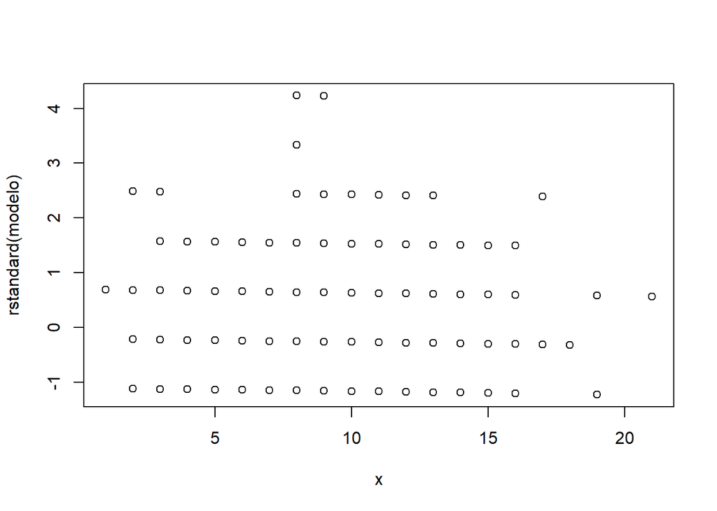

```r
# (6) plote o gráfico dos resíduos normalizados em função do preditor;
plot(x, rstandard(modelo))
```

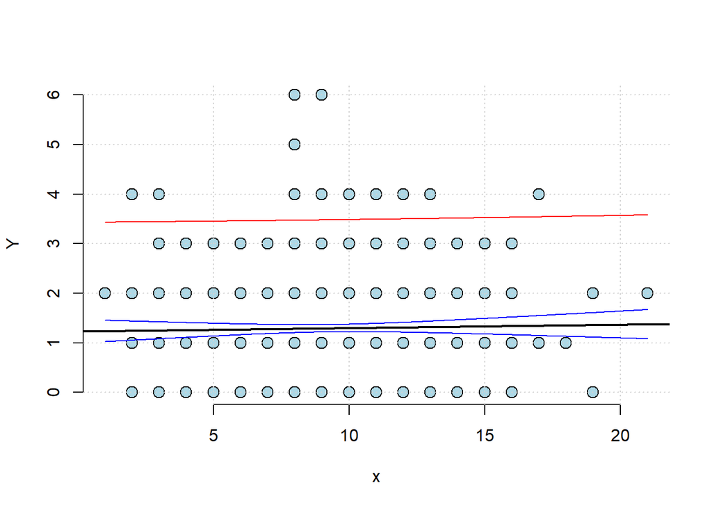

```r
# (7) utilize a função *lmIC* para determinar a banda de confiança e a banda de predição,
lmIC(x, y)
```

```r
# (8) e para fazer inferência sobre um valor qualquer escolhido;
dfpred = data.frame(education=10)
predict(modelo, dfpred, interval='confidence')
```

```
##       fit      lwr      upr
## 1 1.29947 1.223551 1.375389
```

```r
predict(modelo, dfpred, interval='prediction')
```

```
##       fit        lwr      upr
## 1 1.29947 -0.8874916 3.486432
```

```r
# (9) comente os resultados de cada item.
```

Para essa base a conclusão que temos é que não tem uma relação clara entre a quantidade de filhos e a quantidade de anos de educação formal que uma pessoa teve na Suíça naquele ano.

### Exercício 7

Baixe a base de dados *Salaries*, leia o dicionário de dados, escolha duas variáveis e efetue os comandos de 1 a 9.

Essa base representa salários de professores em uma faculdade nos EUA, em 2008 (The 2008-09 nine-month academic salary for Assistant Professors, Associate Professors and Professors in a college in the U.S.). Há 3 variáveis numéricas: yrs.since.phd (anos desde o phd), yrs.service (anos de trabalho) e salary (salário). Vamos verificar se há relação entre o valor recebido e yrs.service.

```r
df = read.csv('Salaries.csv')

# (1) efetue a regressão linear;
formula = salary ~ yrs.service
x = df$yrs.service
y = df$salary
modelo = lm(formula, data = df)

# (2) utilize a função summary e encontre os coeficientes de regressão e o valor de R2;
summary(modelo)
```

```
##
## Call:
## lm(formula = formula, data = df)
##
## Residuals:
##    Min     1Q Median     3Q    Max
## -81933 -20511  -3776  16417 101947
##
## Coefficients:
##             Estimate Std. Error t value Pr(>|t|)
## (Intercept)  99974.7     2416.6   41.37  < 2e-16 ***
## yrs.service    779.6      110.4    7.06 7.53e-12 ***
## ---
## Signif. codes:  0 '***' 0.001 '**' 0.01 '*' 0.05 '.' 0.1 ' ' 1
##
## Residual standard error: 28580 on 395 degrees of freedom
## Multiple R-squared:  0.1121, Adjusted R-squared:  0.1098
## F-statistic: 49.85 on 1 and 395 DF,  p-value: 7.529e-12
```

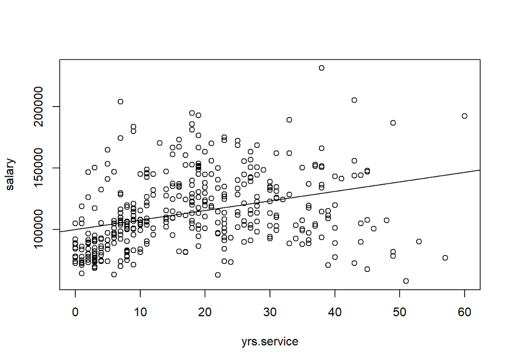

```r
# (3) plote o gráfico de dispersão e a reta de regressão;
plot(formula, data = df)
abline(modelo)
```

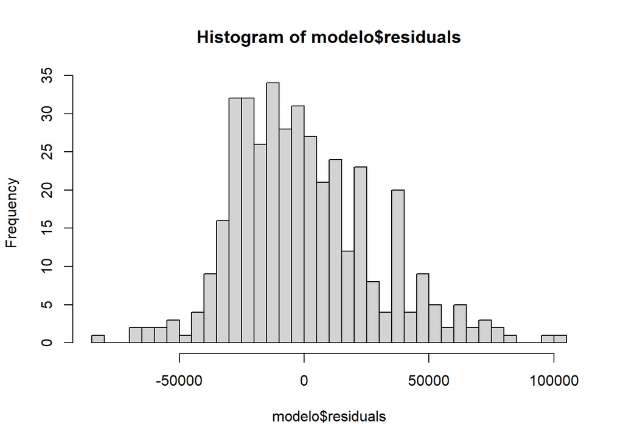

```r
# (4) plote o histograma dos resíduos;
hist(modelo$residuals, breaks=30)
```

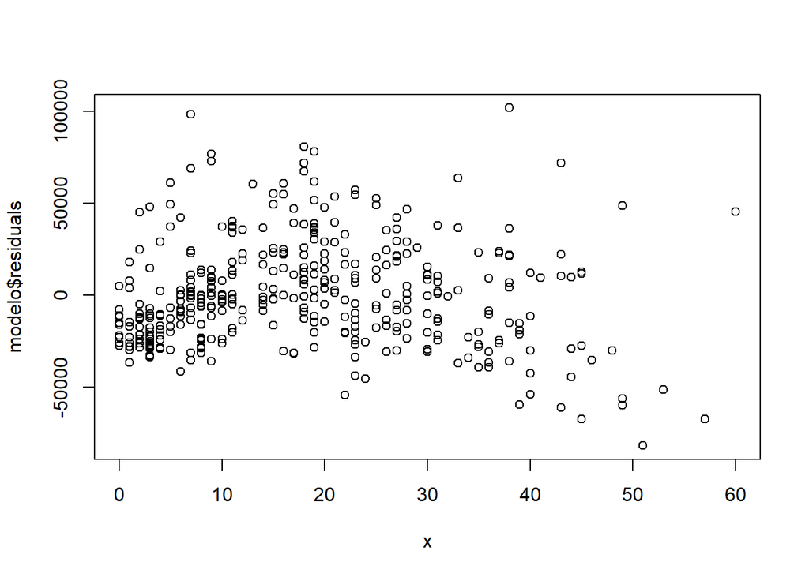

```r
# (5) plote o gráfico dos resíduos em função do preditor;
plot(x, modelo$residuals)
```

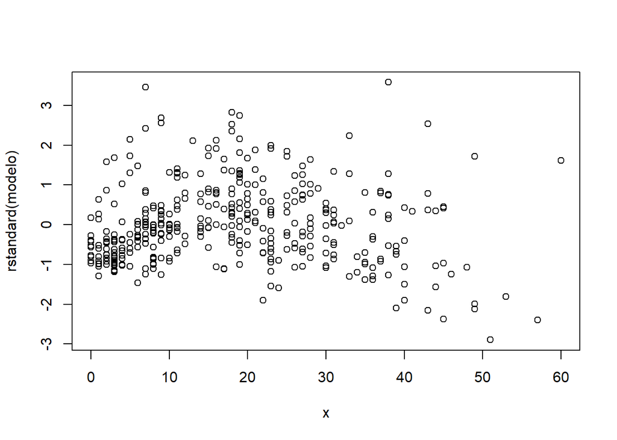

```r
# (6) plote o gráfico dos resíduos normalizados em função do preditor;
plot(x, rstandard(modelo))
```

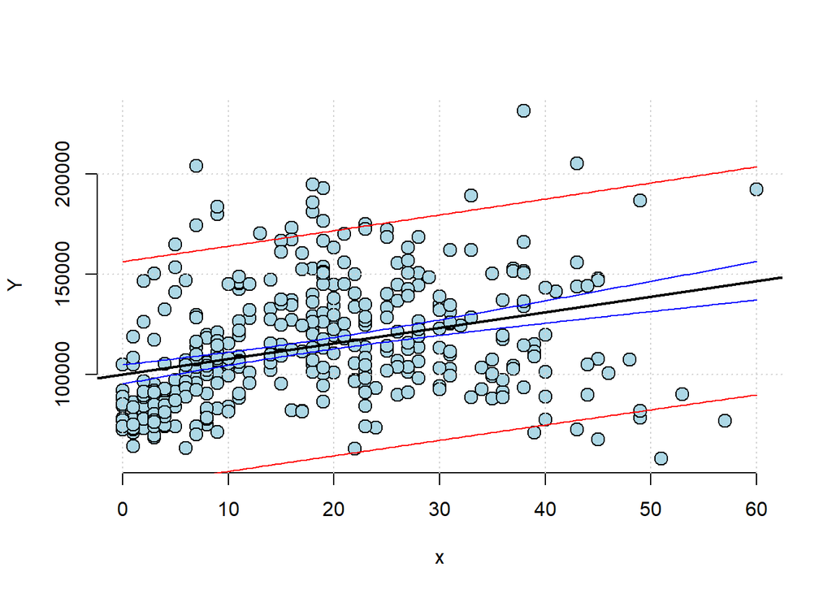

```r
# (7) utilize a função *lmIC* para determinar a banda de confiança e a banda de predição,
lmIC(x, y)
```

```r
# (8) e para fazer inferência sobre um valor qualquer escolhido;
dfpred = data.frame(yrs.service=30)
predict(modelo, dfpred, interval='confidence')
```

```
##        fit      lwr      upr
## 1 123361.7 119465.6 127257.8
```

```r
predict(modelo, dfpred, interval='prediction')
```

```
##        fit      lwr      upr
## 1 123361.7 67043.32 179680.1
```

```r
# (9) comente os resultados de cada item.
```

Os anos de serviços explicam cerca de 11% da variação dos dados. É uma explicação bem pobre. Analisando o gráfico de yrs.service vs salary, vemos que há uma linearidade até uns 15 anos, mas a partir daí os dados passam a ficar bem dispersos. O histograma dos resíduos sugere algum grau de normalidade próxido da média, mas a medida que se distancia da média os resíduos ficam bem diferentes do que seriam caso sua distribuição fosse normal. É um modelo ruim, que explica pouca coisa.

### Efetue os comandos de 1 a 9 para outras três bases de dados de sua escolha.

#### Base 1

Por curiosidade, vamos analisar a base frets.csv, que mostra a relação do tamanho da cabeça do primeiro filho com a do segundo filho. Apenas para ver se o tamanho da cabeça do primeiro filho é um bom preditor para o tamanho da cabeça do segundo filho.

```r
df = read.csv('frets.csv')

# (1) efetue a regressão linear;
formula = l2 ~ l1
x = df$l1
y = df$l2
modelo = lm(formula, data = df)

# (2) utilize a função summary e encontre os coeficientes de regressão e o valor de R2;
summary(modelo)
```

```
##
## Call:
## lm(formula = formula, data = df)
##
## Residuals:
##      Min       1Q   Median       3Q      Max
## -11.0447  -6.2311   0.0312   6.1484  11.4933
##
## Coefficients:
##             Estimate Std. Error t value Pr(>|t|)
## (Intercept)  48.0743    28.0551   1.714      0.1
## l1            0.7310     0.1509   4.846 6.84e-05 ***
## ---
## Signif. codes:  0 '***' 0.001 '**' 0.01 '*' 0.05 '.' 0.1 ' ' 1
##
## Residual standard error: 7.215 on 23 degrees of freedom
## Multiple R-squared:  0.5052, Adjusted R-squared:  0.4837
## F-statistic: 23.48 on 1 and 23 DF,  p-value: 6.842e-05
```

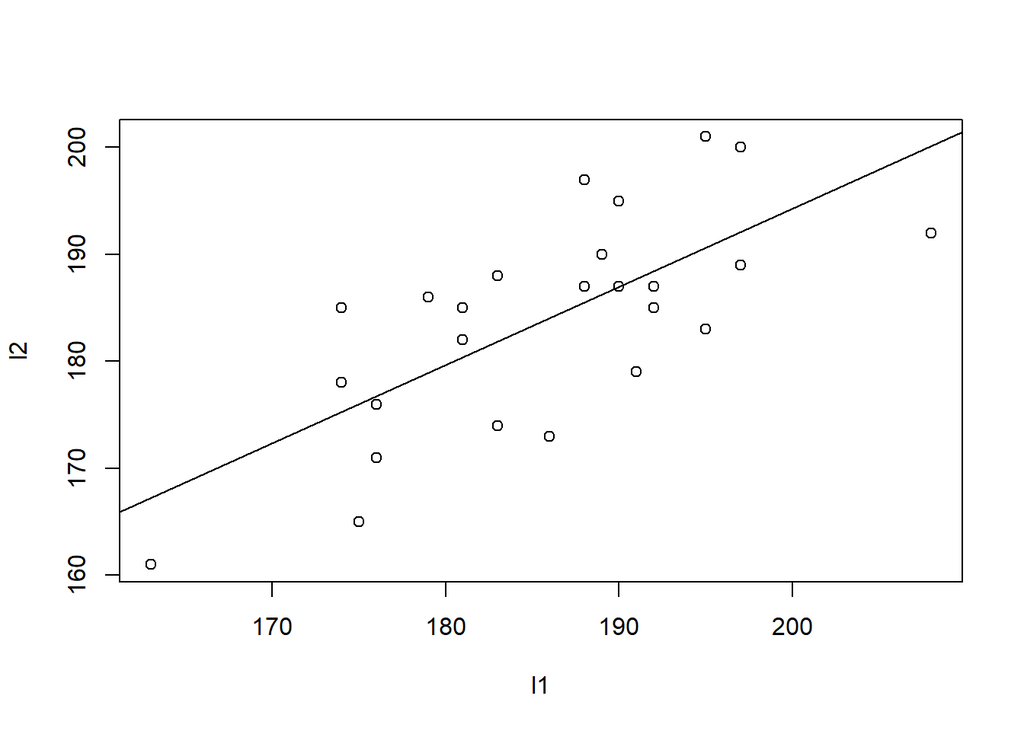

```r
# (3) plote o gráfico de dispersão e a reta de regressão;
plot(formula, data = df)
abline(modelo)
```

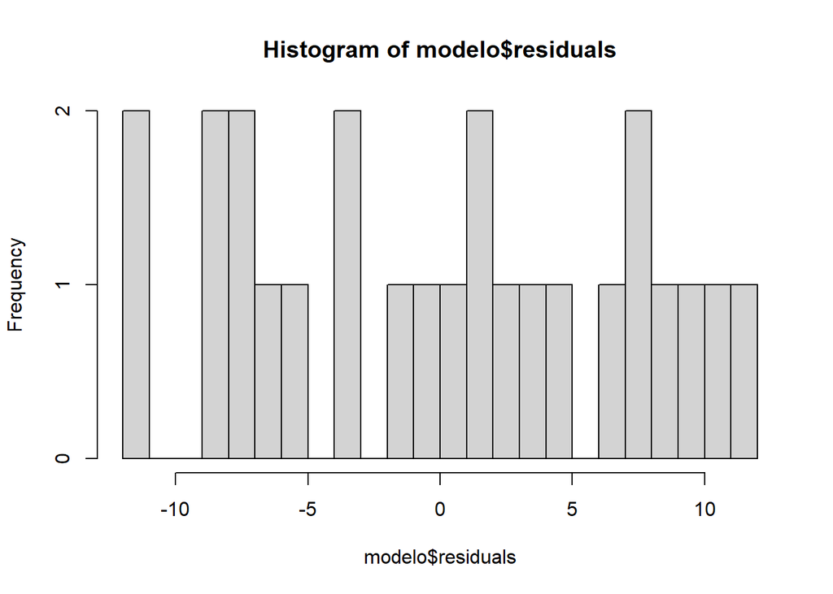

```r
# (4) plote o histograma dos resíduos;
hist(modelo$residuals, breaks=30)
```

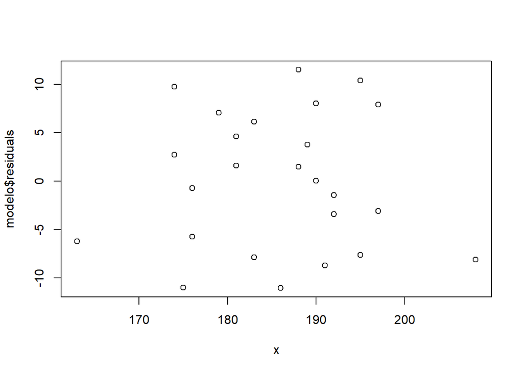

```r
# (5) plote o gráfico dos resíduos em função do preditor;
plot(x, modelo$residuals)
```

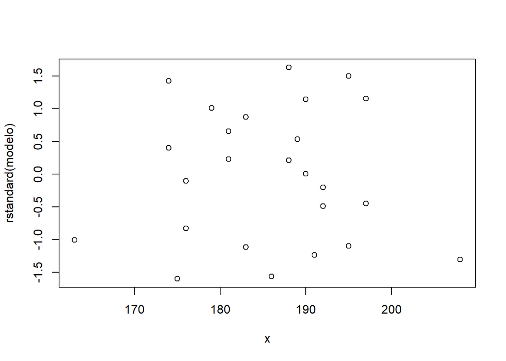

```r
# (6) plote o gráfico dos resíduos normalizados em função do preditor;
plot(x, rstandard(modelo))
```

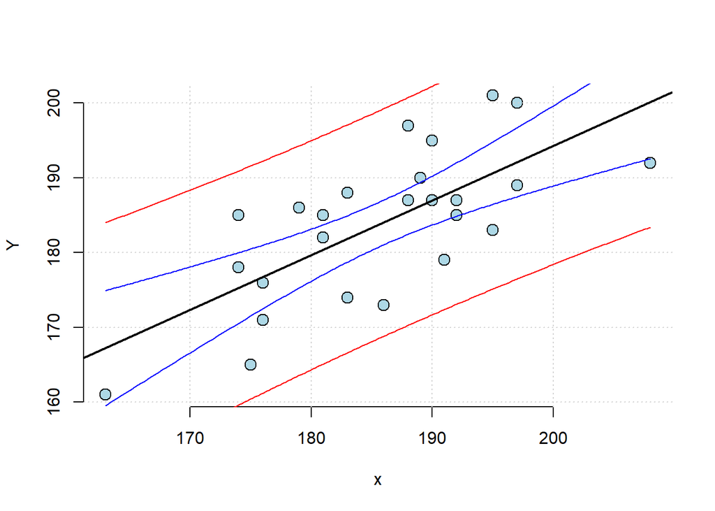

```r
# (7) utilize a função *lmIC* para determinar a banda de confiança e a banda de predição,
lmIC(x, y)
```

```r
# (8) e para fazer inferência sobre um valor qualquer escolhido;
dfpred = data.frame(l1=185)
predict(modelo, dfpred, interval='confidence')
```

```
##        fit      lwr     upr
## 1 183.3137 180.3203 186.307
```

```r
predict(modelo, dfpred, interval='prediction')
```

```
##        fit      lwr      upr
## 1 183.3137 168.0918 198.5355
```

```r
# (9) comente os resultados de cada item.
```

Os dados mostram que, em regra, o tamanho da cabeça do primeiro filho é um bom preditor para o tamanho da cabeça do segundo. É a genética agindo.